# R HW 03

Author

Robsen Gelalcha

Published

September 17, 2026

```r
library(tidyverse)
library(viridis)
library(ggridges)
```

# Exercise 1

The data was collected by the *American National Election Studies*. The data collection for the study began in August 2020 and continued until November 2020. A sample of US eligible voters were surveyed. The sample randomly assigned to one of three groups: web only, mixed web and phone, and mixed video.

# Exercise 2

```r
anes <- read_csv("data/anes2020_subset.csv")
glimpse(anes)
```

```
Rows: 8,280
Columns: 6
$ CASEID     <dbl> 200015, 200022, 200039, 200046, 200053, 200060, 200084, 200…
$ hunt_fish  <dbl> 1, 0, 0, 0, 1, 0, 1, 0, 0, 1, 0, 1, 0, 0, 0, 1, 0, 0, 0, 0,…
$ scientists <dbl> 100, 70, 100, 85, 60, 85, 85, NA, 60, 50, 85, 100, 70, 70, …
$ education  <dbl> 6, 3, 2, 4, 8, 3, 4, 2, 2, 4, 2, 2, 2, 7, 3, 3, 6, 6, 6, 2,…
$ ideology   <dbl> 6, 4, 2, 3, 5, 4, 4, NA, NA, NA, NA, 4, 6, 3, 4, 6, 3, 3, 2…
$ urbanrural <chr> "city", "suburb", "suburb", "small town", "city", "suburb",…
```

- There are 8,280 rows and 6 columns.
- A single row represents an eligible US voter.

# Exercise 3

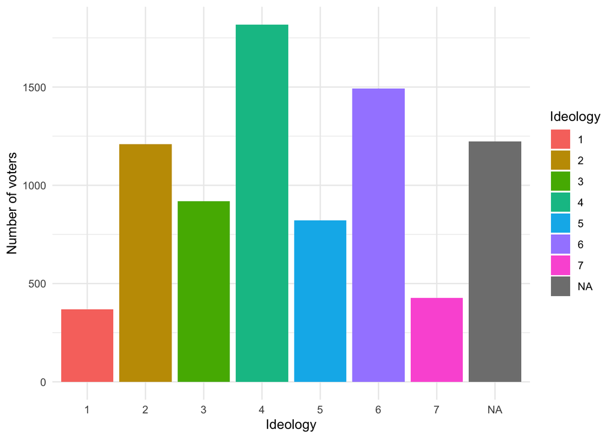

```r
ggplot(anes, aes(x = factor(ideology), fill = factor(ideology))) +
  geom_bar() +

  labs(x = "Ideology", y = "Number of voters", fill = "Ideology") +
  theme_minimal()
```

4 is the most common ideology. The two smallest bars are at the extreme ends of the plot, most respondents aren’t at ideological extremes and tend to be moderate. A considerable number of respondents didn’t disclose their ideology, which should be consiered when interpreting the visualization.

# Exercise 4

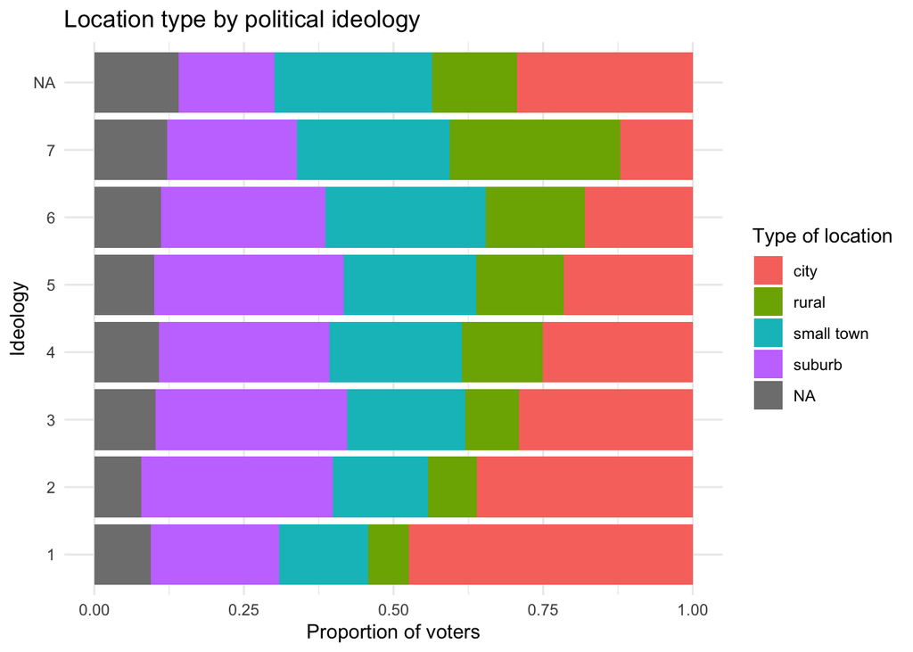

```r
ggplot(anes, aes(y = factor(ideology), fill = urbanrural)) +
  geom_bar(position = "fill") +
  # scale_fill_viridis_d() +
  labs(x = "Proportion of voters",
       y = "Ideology",
       fill = "Type of location",
       title = "Location type by political ideology") +
  theme_minimal()
```

- Suburb and small town have a considerable amount of respondents from each ideology and don’t seem to be dominated by a single one, which contrasts with the rural and urban respondents.
- It’s easier to compare internal composition of ideology groups with proportions. If we were relying on counts, say on the city bar, the liberal cohort would swallow the other groups and it would be harder to make a comparison.
- The proportion of N/A across the ideology bars is fairly consistent and doesn’t vary substantially by ideology.

# Exercise 5

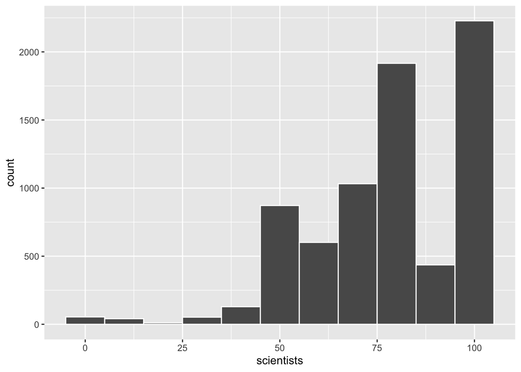

```r
ggplot(anes, aes(x = scientists)) +
  geom_histogram(color = "white", binwidth = 10)
```

# Exercise 6

[figure not shown]

```r
anes |>
  drop_na(hunt_fish, scientists) |>
  mutate(
    hunted_fished = if_else(
      hunt_fish == 0,
      "Did Not Hunt or Fish",
      "Hunted or Fished"
    )
  ) |>
  ggplot(aes(x = hunted_fished, y = ideology, fill = hunted_fished)) +
  geom_boxplot() +
  labs(
    title = "Warmth Toward Scientists by Hunting/Fishing Status",
    x = "Hunting or Fishing Status",
    y = "Feeling Thermometer: Scientists (0–100)",
    fill = NULL
  ) +
  theme(legend.position = "none")
```

# Exercise 7

[figure not shown]

```r
anes |>
  drop_na(hunt_fish, scientists) |>
  mutate(
    hunted_fished = if_else(hunt_fish == 0, "Did Not Hunt or Fish", "Hunted or Fished")
  ) |>
  ggplot(aes(x = ideology, y = hunted_fished, fill = hunted_fished)) +
  geom_density_ridges(alpha = 0.7) +
  labs(
    title = "Warmth Toward Scientists by Hunting/Fishing Status",
    x = "Feeling Thermometer: Scientists (0–100)",
    y = NULL,
    fill = NULL
  ) +
  theme_ridges() +
  theme(legend.position = "none")
```

# Exercise 8

# Exercise 9

- I don’t think so, Scatterplots are useful when the variables are continuous. The scatterplot is essentially serving as a less useful barplot.
- The intervals here aren’t acceptable. We are accepting that the gap between 6 and 7 (highschool grad and university grad) is the same as 7 and 8 (bachlors and PhD/Masters).
- It only slightly makes sense. There’s a positive slope (more education, more appriciation for scientists).
- I think density ridge would do a better job.

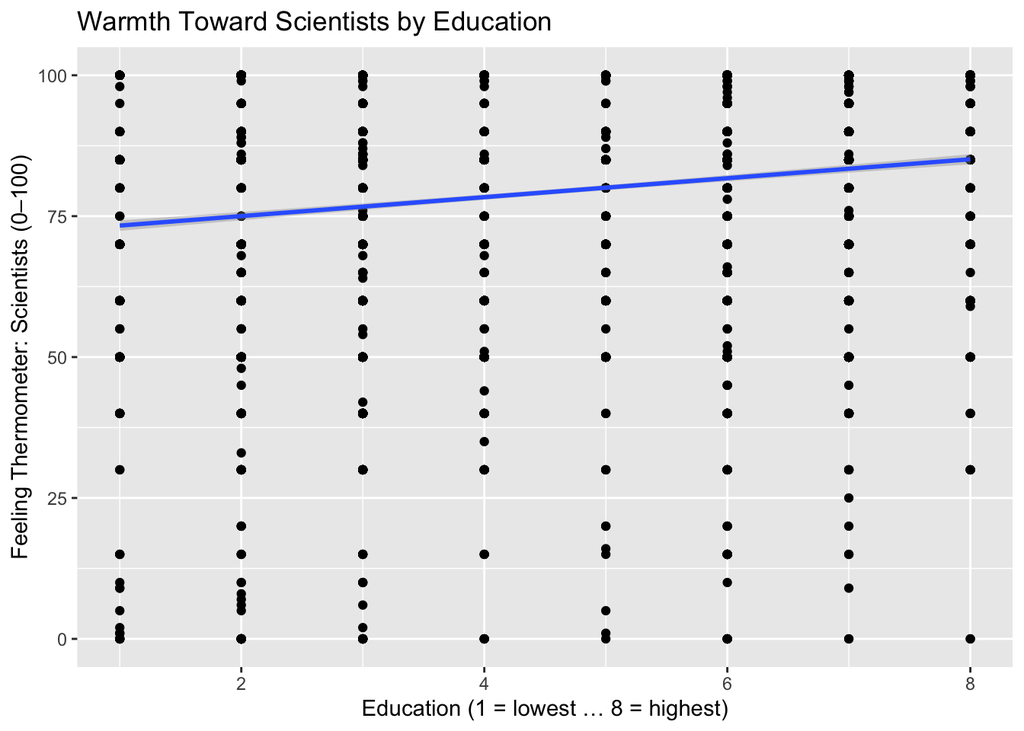

```r
anes |>
  drop_na(education, scientists) |>
  ggplot(aes(x = education, y = scientists)) +
  geom_point() +
  geom_smooth(method = "lm") +
  labs(
    title = "Warmth Toward Scientists by Education",
    x = "Education (1 = lowest … 8 = highest)",
    y = "Feeling Thermometer: Scientists (0–100)"
  )
```

# Exercise 10

- Is there a relationship between the type of place respondents reside and whether they’re into hunting/fishing?
- `hunt_fish` and `urbanrural`

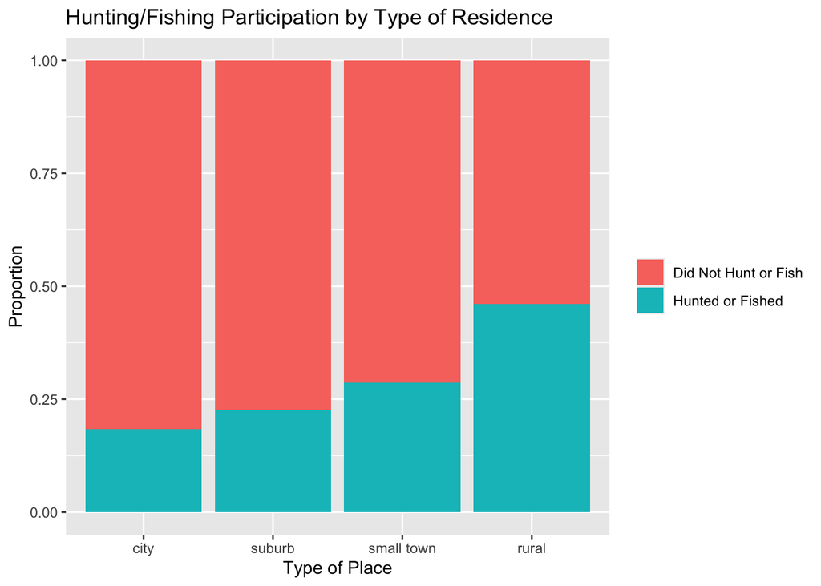

```r
anes |>
  drop_na(hunt_fish, urbanrural) |>
  mutate(
    hunted_fished = if_else(hunt_fish == 0, "Did Not Hunt or Fish", "Hunted or Fished"),

    urbanrural = factor(urbanrural, levels = c("city", "suburb", "small town", "rural"))
  ) |>
  ggplot(aes(x = urbanrural, fill = hunted_fished)) +
  geom_bar(position = "fill") +
  labs(
    title = "Hunting/Fishing Participation by Type of Residence",
    x = "Type of Place",
    y = "Proportion",
    fill = NULL
  )
```

- Since both are categorical variables, we’re interested in their counts. Also, since the number of respondents between the type of residence varies wildly, the proportion is ideal as we’re more interested about the binary within the population. It’s for this reason that a stacked, proportion-filled bar plot is the most ideal.
- Unsurprisingly, the closer a person is to the city, the less likely to engage in hunting or fishing.

# Exercise 11